# M01-02-coding-basics_answers.R

```r
## Data structures -------------------------------------------------------------

# We have explored data structures in R and how to access their value

# Replace _ to complete expressions and return the correct answer

# Restart R to remove previous results using: Ctrl/Cmd + shift + F10
```

```r
## 1. Warm up ----
```

The following is a vector with numbers and text. In this case, R will convert all the numbers to text - NOT what we want. We cannot divide the text by 5 …

```r
# Why does not this calculation work?
my_numbers <- c(1, 4, 3, 'missing', 6, 7)
my_numbers / 5
```

```
## Error in my_numbers/5: non-numeric argument to binary operator
```

The following prints to the console and shows they are text e.g. `"1"` and not `1`

```r
# What type of values are in my_numbers?
my_numbers
```

```
## [1] "1"       "4"       "3"       "missing" "6"       "7"
```

The following shows that if we do a calculation on each number, then the `NA` result is `NA`

```r
# What happens if we do vector arithmetic with NA present?
has_NA <- c(1, 4, 3, NA, 6, 7)
has_NA / 5
```

```
## [1] 0.2 0.8 0.6  NA 1.2 1.4
```

If we use a summary calculation on a vector with `NA`, then the result is `NA`. We have to use the argument `na.rm=TRUE` so the `mean()` function excludes ’ `NA` in the calculation (described in the help documention).

```r
# What happens if we do a summary statistic (mean, sum, ...) with NA present?
# How can you produce a mean value here? Use ?mean
mean(has_NA)
```

```
## [1] NA
```

```r
mean(has_NA, na.rm = TRUE)
```

```
## [1] 4.2
```

```r
## 2. Selecting elements in a vector ----

# Here are two vectors for the following exercises
weights <- c(54, 67, 72, 76, 73, 70, 80, 69, 66, 82)

species <-
  c('virginica', 'setosa', 'setosa', 'versicolor', 'versicolor',
    'versicolor', 'versicolor', 'setosa', 'versicolor', 'setosa')


# 2.1 ----
# What type of vector is `weights`?
# class(_)
class(weights)
```

```
## [1] "numeric"
```

```r
# Return the first 5 values of weights
# weights[_]
weights[1:5]
```

```
## [1] 54 67 72 76 73
```

We use conditional selection  
- `weights > 70` will create a vector of TRUE/FALSE  
- we include above within the `[]`

```r
# Return the values of weights less than 70
# weights
weights[ weights > 70 ]
```

```
## [1] 72 76 73 80 82
```

We use `&`

```r
# Return the values of weights greater than 70 and less than 80
weights[ weights > 70 & weights < 80]
```

```
## [1] 72 76 73
```

```r
# 2.2 ----
```

Hopefully you copied the `class()` code from above

```r
# What type of vector is `species`?
class(species)
```

```
## [1] "character"
```

We use conditional selection  
- `species == 'setosa'` will create a vector of TRUE/FALSE  
- we include above within the `[]`

```r
# Return the values of only the 'setosa' from species
# species[_]
species[ species == 'setosa' ]
```

```
## [1] "setosa" "setosa" "setosa" "setosa"
```

```r
# Return the values of 'setosa' and 'versicolor' from species
#species[_]
species[ species == 'setosa' | species == 'versicolor' ]
```

```
## [1] "setosa"     "setosa"     "versicolor" "versicolor" "versicolor"
## [6] "versicolor" "setosa"     "versicolor" "setosa"
```

```r
species[ species %in% c('setosa', 'versicolor') ]
```

```
## [1] "setosa"     "setosa"     "versicolor" "versicolor" "versicolor"
## [6] "versicolor" "setosa"     "versicolor" "setosa"
```

```r
# 2.3 ----
# R has some built-in vectors of useful words
?Constants
```

```r
# Return the first 5 letters of the alphabet in lower-case
letters[1:5]
```

```
## [1] "a" "b" "c" "d" "e"
```

```r
# Return the last 5 letters of the alphabet in upper-case
LETTERS[21:26]
```

```
## [1] "U" "V" "W" "X" "Y" "Z"
```

```r
# Return the 6th month of year
month.name[6]
```

```
## [1] "June"
```

```r
## 3. Selecting elements in a matrix ----

# Here is a matrix for the following exercises
weekly_weights <-
  matrix(data = c(71, 71, 81, 75, 73, 67, 58, 68, 79, 68,
                  64, 75, 54, 74, 84, 53, 75, 76, 80, 73,
                  65, 78, 71, 70, 67, 61, 71, 73, 72, 73),
         ncol = 3,
         dimnames = list(NULL, c('wk1', 'wk2', 'wk3')))

# Confirm the `weekly_weights` is a `matrix`
class(weekly_weights)
```

```
## [1] "matrix" "array"
```

Google ‘how to obtain column names of a matrix’

```r
# Return the column names
colnames(weekly_weights)
```

```
## [1] "wk1" "wk2" "wk3"
```

```r
# Does `weekly_weights` have row names?
rownames(weekly_weights) # no
```

[output not shown]

Rememeber `[rows, columns]`

```r
# Return the second column
weekly_weights[ , 2]
```

```
##  [1] 64 75 54 74 84 53 75 76 80 73
```

```r
# Return the `wk3` column by using it's name
weekly_weights[ , 'wk3']
```

```
##  [1] 65 78 71 70 67 61 71 73 72 73
```

```r
# Return the first 5 rows
weekly_weights[ 1:5, ]
```

```
##      wk1 wk2 wk3
## [1,]  71  64  65
## [2,]  71  75  78
## [3,]  81  54  71
## [4,]  75  74  70
## [5,]  73  84  67
```

```r
# Return the 2nd value of the wk2 column
weekly_weights[ 2, 'wk3']
```

```
## wk3
##  78
```

Google ‘how to obtain row means of a matrix’

```r
# Return the mean of each row
rowMeans(weekly_weights)
```

```
##  [1] 66.66667 74.66667 68.66667 73.00000 74.66667 60.33333 68.00000 72.33333
##  [9] 77.00000 71.33333
```

Were you able to guess this one?

```r
# Return the sum of each column
colSums(weekly_weights)
```

```
## wk1 wk2 wk3
## 711 708 701
```

This one was too hard … It used `[]` twice - one for the `weekly_weights[,'wk3'] > 70` - which was included in `weekly_weights[here, ]`

```r
# Return the rows where wk3 values are > than 70
weekly_weights[ weekly_weights[,'wk3'] > 70 , ]
```

```
##      wk1 wk2 wk3
## [1,]  71  75  78
## [2,]  81  54  71
## [3,]  58  75  71
## [4,]  68  76  73
## [5,]  79  80  72
## [6,]  68  73  73
```

We google suggested the transpose function `t()`

```r
# Plot each row as a line using matplot. After your first attempt, you may notice
# that the data is in the wrong orientation - the rows need to be the columns
# and columns the rows, that is you need to transpose the matrix. Try searching
# on the internet "how to transpose a matrix in R"
# ?matplot
```

The first time, you may have noticed only 3 lines - it was plotting the columns so we transpose it to make the original rows the columns

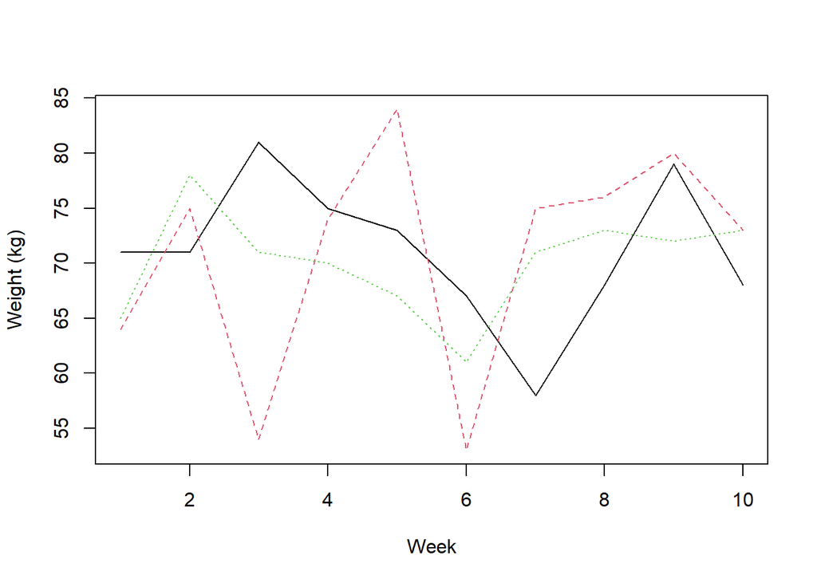

```r
matplot(x = weekly_weights, type = 'l', ylab = 'Weight (kg)', xlab = 'Week')
```

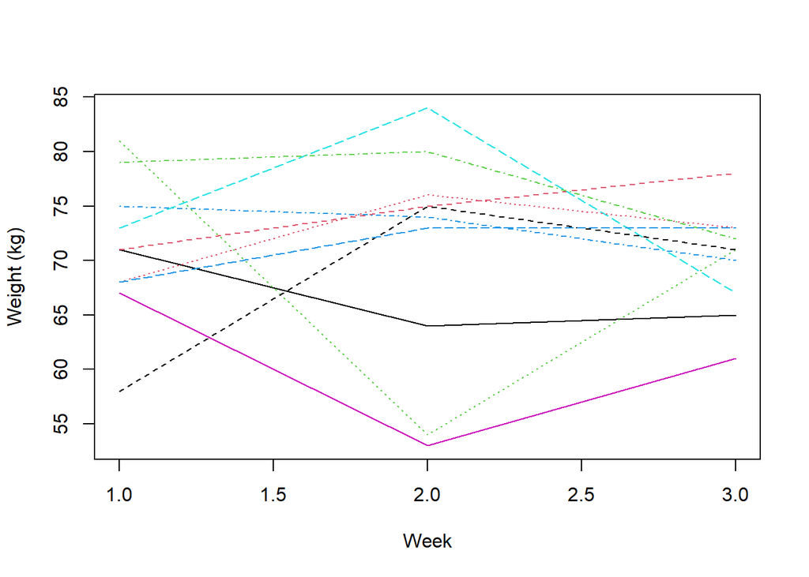

```r
matplot(x = t(weekly_weights), type = 'l', ylab = 'Weight (kg)', xlab = 'Week')
```

```r
## 4. Selecting elements in a list ----

# An example list for the following exercise
person_list <-
  list(
    date_accessed = Sys.Date(),
    num_records = 3,
    data =
      list(
        data.frame(person = 'Tom', age = 5),
        data.frame(person = 'Jerry', age = 2),
        data.frame(person = 'Quacker', age = 10)
      )
  )

# Confirm the `person_list` is a `list`
class(person_list)
```

```
## [1] "list"
```

```r
# The str() command can help visualise a list
str(person_list)
```

```
## List of 3
##  $ date_accessed: Date[1:1], format: "2024-05-21"
##  $ num_records  : num 3
##  $ data         :List of 3
##   ..$ :'data.frame': 1 obs. of  2 variables:
##   .. ..$ person: chr "Tom"
##   .. ..$ age   : num 5
##   ..$ :'data.frame': 1 obs. of  2 variables:
##   .. ..$ person: chr "Jerry"
##   .. ..$ age   : num 2
##   ..$ :'data.frame': 1 obs. of  2 variables:
##   .. ..$ person: chr "Quacker"
##   .. ..$ age   : num 10
```

```r
# Return the element `date_accessed`
person_list$date_accessed
```

```
## [1] "2024-05-21"
```

```r
person_list[['date_accessed']]
```

```
## [1] "2024-05-21"
```

```r
# Return the element containing person `Tom`
# Remember: the `data` element is an unnamed is a List of 3
person_list$data[[1]]
```

```
##   person age
## 1    Tom   5
```

```r
## 5. Selecting elements in a data.frame ----

# The data.frame will be the most used data structure from here on. Here, we will
# use some traditional methods for interacting with them but later we will use
# different (and clearer) methods to do them.

# iris is a built-in dataset in R
```

```r
iris
```

```r
# If a data.frame is big and we print to the console, it is often unmanageable to
# read. Using head() only shows the first 6 rows. We will later use a tibble
# data.frame that has better properties.
head(iris)
```

```
##   Sepal.Length Sepal.Width Petal.Length Petal.Width Species
## 1          5.1         3.5          1.4         0.2  setosa
## 2          4.9         3.0          1.4         0.2  setosa
## 3          4.7         3.2          1.3         0.2  setosa
## 4          4.6         3.1          1.5         0.2  setosa
## 5          5.0         3.6          1.4         0.2  setosa
## 6          5.4         3.9          1.7         0.4  setosa
```

In the following, we see  
- ‘data.frame’: 150 obs. of 5 variables  
- num and Factor  
- Factor w/ 3 levels “setosa”,“versicolor”

```r
# Using the str() function on iris,
# 1. How many rows and columns are there?
# 2. What data vectors are present?
# 3. How many different values exist for the column `Species`?
str(iris)
```

```
## 'data.frame':    150 obs. of  5 variables:
##  $ Sepal.Length: num  5.1 4.9 4.7 4.6 5 5.4 4.6 5 4.4 4.9 ...
##  $ Sepal.Width : num  3.5 3 3.2 3.1 3.6 3.9 3.4 3.4 2.9 3.1 ...
##  $ Petal.Length: num  1.4 1.4 1.3 1.5 1.4 1.7 1.4 1.5 1.4 1.5 ...
##  $ Petal.Width : num  0.2 0.2 0.2 0.2 0.2 0.4 0.3 0.2 0.2 0.1 ...
##  $ Species     : Factor w/ 3 levels "setosa","versicolor",..: 1 1 1 1 1 1 1 1 1 1 ...
```

```r
# Return the column names
colnames(iris)
```

```
## [1] "Sepal.Length" "Sepal.Width"  "Petal.Length" "Petal.Width"  "Species"
```

```r
names(iris)
```

```
## [1] "Sepal.Length" "Sepal.Width"  "Petal.Length" "Petal.Width"  "Species"
```

```r
# Return the `Species` column using $
iris$Species
```

```
##   [1] setosa     setosa     setosa     setosa     setosa     setosa
##   [7] setosa     setosa     setosa     setosa     setosa     setosa
##  [13] setosa     setosa     setosa     setosa     setosa     setosa
##  [19] setosa     setosa     setosa     setosa     setosa     setosa
##  [25] setosa     setosa     setosa     setosa     setosa     setosa
##  [31] setosa     setosa     setosa     setosa     setosa     setosa
##  [37] setosa     setosa     setosa     setosa     setosa     setosa
##  [43] setosa     setosa     setosa     setosa     setosa     setosa
##  [49] setosa     setosa     versicolor versicolor versicolor versicolor
##  [55] versicolor versicolor versicolor versicolor versicolor versicolor
##  [61] versicolor versicolor versicolor versicolor versicolor versicolor
##  [67] versicolor versicolor versicolor versicolor versicolor versicolor
##  [73] versicolor versicolor versicolor versicolor versicolor versicolor
##  [79] versicolor versicolor versicolor versicolor versicolor versicolor
##  [85] versicolor versicolor versicolor versicolor versicolor versicolor
##  [91] versicolor versicolor versicolor versicolor versicolor versicolor
##  [97] versicolor versicolor versicolor versicolor virginica  virginica
## [103] virginica  virginica  virginica  virginica  virginica  virginica
## [109] virginica  virginica  virginica  virginica  virginica  virginica
## [115] virginica  virginica  virginica  virginica  virginica  virginica
## [121] virginica  virginica  virginica  virginica  virginica  virginica
## [127] virginica  virginica  virginica  virginica  virginica  virginica
## [133] virginica  virginica  virginica  virginica  virginica  virginica
## [139] virginica  virginica  virginica  virginica  virginica  virginica
## [145] virginica  virginica  virginica  virginica  virginica  virginica
## Levels: setosa versicolor virginica
```

```r
# Return the `Sepal.Length` column using [[]]
iris[['Sepal.Length']]
```

```
##   [1] 5.1 4.9 4.7 4.6 5.0 5.4 4.6 5.0 4.4 4.9 5.4 4.8 4.8 4.3 5.8 5.7 5.4 5.1
##  [19] 5.7 5.1 5.4 5.1 4.6 5.1 4.8 5.0 5.0 5.2 5.2 4.7 4.8 5.4 5.2 5.5 4.9 5.0
##  [37] 5.5 4.9 4.4 5.1 5.0 4.5 4.4 5.0 5.1 4.8 5.1 4.6 5.3 5.0 7.0 6.4 6.9 5.5
##  [55] 6.5 5.7 6.3 4.9 6.6 5.2 5.0 5.9 6.0 6.1 5.6 6.7 5.6 5.8 6.2 5.6 5.9 6.1
##  [73] 6.3 6.1 6.4 6.6 6.8 6.7 6.0 5.7 5.5 5.5 5.8 6.0 5.4 6.0 6.7 6.3 5.6 5.5
##  [91] 5.5 6.1 5.8 5.0 5.6 5.7 5.7 6.2 5.1 5.7 6.3 5.8 7.1 6.3 6.5 7.6 4.9 7.3
## [109] 6.7 7.2 6.5 6.4 6.8 5.7 5.8 6.4 6.5 7.7 7.7 6.0 6.9 5.6 7.7 6.3 6.7 7.2
## [127] 6.2 6.1 6.4 7.2 7.4 7.9 6.4 6.3 6.1 7.7 6.3 6.4 6.0 6.9 6.7 6.9 5.8 6.8
## [145] 6.7 6.7 6.3 6.5 6.2 5.9
```

```r
# Return the `Petal.Width` and `Species` columns using [,]
iris[ , c('Petal.Width', 'Species')]
```

```
##     Petal.Width    Species
## 1           0.2     setosa
## 2           0.2     setosa
## 3           0.2     setosa
## 4           0.2     setosa
## 5           0.2     setosa
## 6           0.4     setosa
## 7           0.3     setosa
## 8           0.2     setosa
## 9           0.2     setosa
## 10          0.1     setosa
## 11          0.2     setosa
## 12          0.2     setosa
## 13          0.1     setosa
## 14          0.1     setosa
```

[output cut: 136 more lines]

```r
# Return the first 2 rows of data
iris[ 1:2, ]
```

```
##   Sepal.Length Sepal.Width Petal.Length Petal.Width Species
## 1          5.1         3.5          1.4         0.2  setosa
## 2          4.9         3.0          1.4         0.2  setosa
```

```r
# Return the row where the `Petal.Length` is greater than 3.5
iris[ iris$Petal.Length > 3.5 , ]
```

```
##     Sepal.Length Sepal.Width Petal.Length Petal.Width    Species
## 51           7.0         3.2          4.7         1.4 versicolor
## 52           6.4         3.2          4.5         1.5 versicolor
## 53           6.9         3.1          4.9         1.5 versicolor
## 54           5.5         2.3          4.0         1.3 versicolor
## 55           6.5         2.8          4.6         1.5 versicolor
## 56           5.7         2.8          4.5         1.3 versicolor
## 57           6.3         3.3          4.7         1.6 versicolor
## 59           6.6         2.9          4.6         1.3 versicolor
## 60           5.2         2.7          3.9         1.4 versicolor
## 62           5.9         3.0          4.2         1.5 versicolor
## 63           6.0         2.2          4.0         1.0 versicolor
## 64           6.1         2.9          4.7         1.4 versicolor
## 65           5.6         2.9          3.6         1.3 versicolor
## 66           6.7         3.1          4.4         1.4 versicolor
```

[output cut: 81 more lines]

```r
# Return the data of only the Species `versicolor`
iris[ iris$Species == 'versicolor', ]
```

```
##     Sepal.Length Sepal.Width Petal.Length Petal.Width    Species
## 51           7.0         3.2          4.7         1.4 versicolor
## 52           6.4         3.2          4.5         1.5 versicolor
## 53           6.9         3.1          4.9         1.5 versicolor
## 54           5.5         2.3          4.0         1.3 versicolor
## 55           6.5         2.8          4.6         1.5 versicolor
## 56           5.7         2.8          4.5         1.3 versicolor
## 57           6.3         3.3          4.7         1.6 versicolor
## 58           4.9         2.4          3.3         1.0 versicolor
## 59           6.6         2.9          4.6         1.3 versicolor
## 60           5.2         2.7          3.9         1.4 versicolor
## 61           5.0         2.0          3.5         1.0 versicolor
## 62           5.9         3.0          4.2         1.5 versicolor
## 63           6.0         2.2          4.0         1.0 versicolor
## 64           6.1         2.9          4.7         1.4 versicolor
```

[output cut: 36 more lines]

The follow we select columns of the data.frame using `$` in many locations

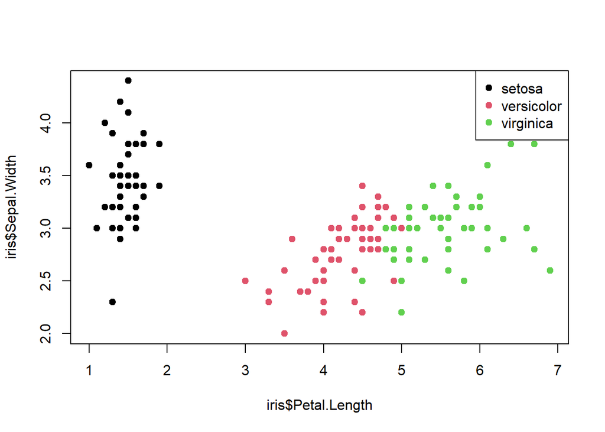

```r
# Create a plot of sepal length and width, coloured by species, by selecting them
# from the dataframe for the arguments below.
# plot(x = _, y = _, col = _, pch = 19)
# legend('topright', legend = levels(iris$Species), col = 1:3, pch = 19)
plot(x = iris$Petal.Length, y = iris$Sepal.Width, col = iris$Species, pch = 19)
legend('topright', legend = levels(iris$Species), col = 1:3, pch = 19)
```

```r
# faithful is a dataset included in R of the time between eurptions of a geyser
# in Yellowstone National Park
head(faithful)
```

```
##   eruptions waiting
## 1     3.600      79
## 2     1.800      54
## 3     3.333      74
## 4     2.283      62
## 5     4.533      85
## 6     2.883      55
```

```r
?faithful
```

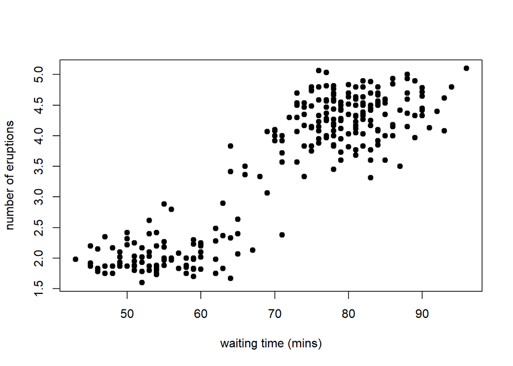

```r
# Plot the number of eruptions by waiting time
plot(x = faithful$waiting, y = faithful$eruptions,
     pch = 19,
     xlab = 'waiting time (mins)',
     ylab = 'number of eruptions')
```

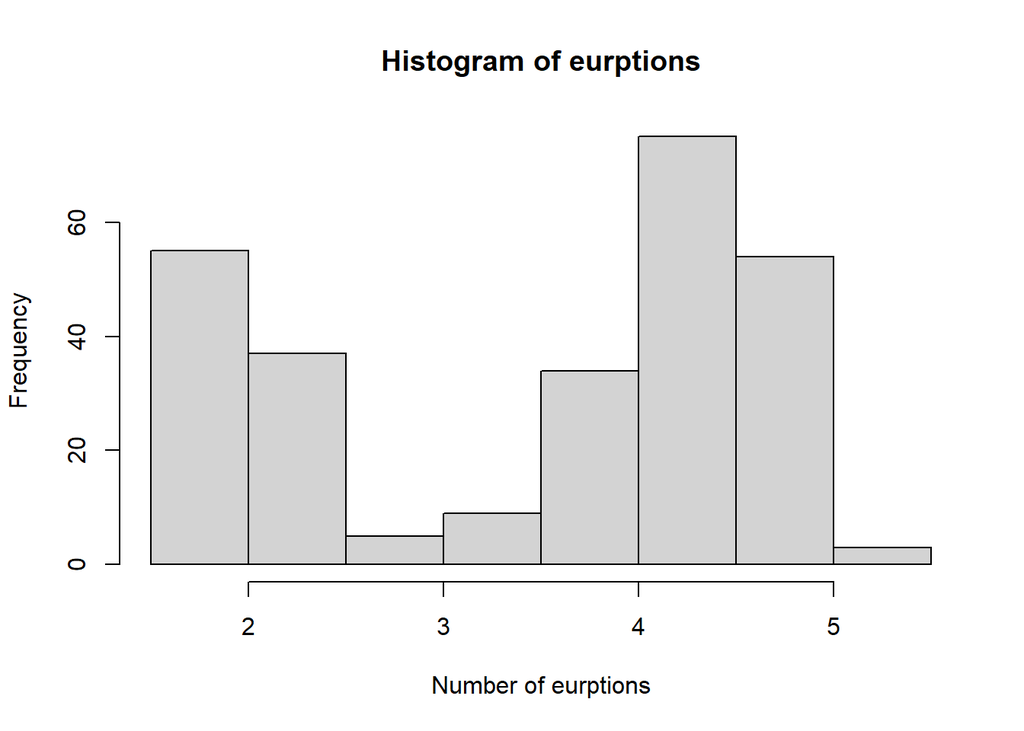

```r
# Plot a histogram of the number of eruptions
# Can you change:
#  the title to "Histogram of eurptions" and
#  x axis title to "Number of eurptions"?
hist(x = faithful$eruptions, xlab = 'Number of eurptions', main = 'Histogram of eurptions')
```